# 生存分析

## 1. 分析生存率和绘制生存曲线

1-2 中位生存时间及其95%可信区间： 18.0 13.0 21.0

1-3 A组中位生存时间及其95%CI： 19.0 13.0 28.0

1-4 B组中位生存时间及其95%CI： 17.0 9.0 21.0

### 1-1 不同时间（月）的生存率

这些值表示在不同时间点的生存率，即患者在该时间点仍然存活的概率。例如： -

- 在1个月时，生存率为0.978723，即97.87%的患者在1个月后仍然存活。
- 在5个月时，生存率为0.934236，即93.42%的患者在5个月后仍然存活。
- 在10个月时，生存率为0.728667，即72.87%的患者在10个月后仍然存活。
- 在15个月时，生存率为0.607898，即60.79%的患者在15个月后仍然存活。
- 在20个月时，生存率为0.376770，即37.68%的患者在20个月后仍然存活。
- 在25个月时，生存率为0.239219，即23.92%的患者在25个月后仍然存活。
- 在30个月时，生存率为0.149512，即14.95%的患者在30个月后仍然存活。
- 在35个月时，生存率为0.079740，即7.97%的患者在35个月后仍然存活。
- 在40个月时，生存率为0.039870，即3.99%的患者在40个月后仍然存活。
- 在45个月时，生存率为0.039870，即3.99%的患者在45个月后仍然存活。

### 1-2 中位生存时间及其95%可信区间

中位生存时间是生存率下降到50%时的时间点。这里中位生存时间为18个月，表示一半的患者在18个月后仍然存活，另一半则已经死亡。

95%可信区间为[13.0,21.0]，表示我们有95%的把握认为中位生存时间在这个区间内。

### 1-3 A组中位生存时间及其95%CI

A组的中位生存时间为19个月，95%可信区间为[13.0,28.0]。这表示A组有一半的患者在19个月后仍然存活，另一半则已经死亡。我们有95%的把握认为A组的中位生存时间在这个区间内。

### 1-4 B组中位生存时间及其95%CI

B组的中位生存时间为17个月，95%可信区间为[9.0,21.0]。这表示B组有一半的患者在17个月后仍然存活，另一半则已经死亡。我们有95%的把握认为B组的中位生存时间在这个区间内。

### 总结

从上述结果可以看出，A组的中位生存时间（19个月）比B组（17个月）长，但两组的95%可信区间有重叠，这表明两组之间的生存时间差异可能不具有统计学意义。为了进一步验证这一点，可以进行Log-Rank检验来比较两组的生存曲线。此外，生存曲线图可以直观地展示两组的生存率随时间的变化情况。

### 1-5 绘图实践结果

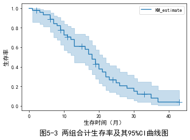

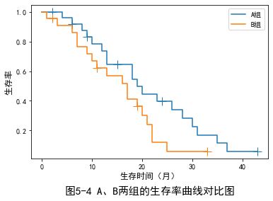

这两个图是生存分析中的Kaplan-Meier生存曲线图，用于展示不同组别随时间变化的生存率。下面是对每个图的详细解读：

### 图5-3 两组合计生存率及其95%CI曲线图

1. **生存曲线**：图中的蓝色曲线代表了两组合并后的生存率估计。生存率从1开始，随着时间的推移逐渐下降。
2. **生存时间（月）**：横轴表示生存时间，以月为单位。
3. **生存率**：纵轴表示生存率，即在特定时间点上仍然存活的个体比例。
4. **95%置信区间（CI）**：曲线周围的浅蓝色区域表示生存率的95%置信区间，反映了生存率估计的不确定性。置信区间越窄，估计越精确。
5. **阶梯状下降**：生存曲线的阶梯状下降表示在特定时间点有事件发生（如死亡），导致生存率下降。
6. **删失数据**：图中的垂直短线表示删失数据，即在特定时间点上，个体的确切生存状态未知。

总的来说，这两个图提供了关于两组生存情况的直观比较，可以帮助研究人员或医生理解不同因素对生存率的影响。

## 2. 分析死亡风险和绘制累积死亡概率曲线

在生存分析中，累积死亡概率曲线是生存函数的补数，它表示在特定时间点之前死亡的概率。以下是对您提供的实践结果的详细解读：

### 2-1 A组累积死亡概率

- **累积死亡概率**：这是A组在不同时间点的累积死亡概率。

例如，在时间点2个月时，累积死亡概率为0，表示在2个月时没有患者死亡；在时间点4个月时，累积死亡概率为0.041667，表示在4个月时，大约有4.17%的A组患者已经死亡。

- **时间线（timeline）**：表示不同的时间点，用于计算累积死亡概率。

### 2-2 B组累积死亡概率

- **累积死亡概率**：这是B组在不同时间点的累积死亡概率。

例如，在时间点1个月时，累积死亡概率为0.045455，表示在1个月时，大约有4.55%的B组患者已经死亡；在时间点22个月时，累积死亡概率为0.879356，表示在22个月时，大约有87.94%的B组患者已经死亡。

### 图5-5 A、B两组的累积死亡概率对比图

- **累积死亡概率曲线**：图中展示了A组和B组的累积死亡概率随时间的变化。曲线从0开始，随着时间的推移逐渐上升。
- **时间（月）**：横轴表示时间，以月为单位。
- **累积死亡概率**：纵轴表示累积死亡概率，即在特定时间点之前死亡的个体比例。
- **曲线对比**：通过比较两条曲线，可以观察到不同组别在不同时间点的累积死亡概率差异。如果一条曲线始终高于另一条，这表明该组的累积死亡概率更高，即死亡风险更大。
- **曲线的陡峭程度**：曲线上升的陡峭程度表示死亡事件的集中程度。陡峭的上升可能表示在某个时间段内死亡事件较为集中。

### 结论

- **死亡风险比较**：通过比较A组和B组的累积死亡概率曲线，可以评估不同治疗或条件对死亡风险的影响。如果A组的累积死亡概率曲线始终低于B组，这可能表明A组的治疗或条件更有利于降低死亡风险。
- **时间点分析**：可以观察到在特定时间点，两组的累积死亡概率差异，这对于理解治疗或条件在不同阶段的效果具有重要意义。

### 2-3 绘图实践结果

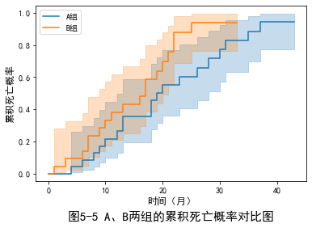

这张图是A组和B组的累积死亡概率对比图，它展示了两组在不同时间点的累积死亡概率。以下是对图中信息的详细解读：

1. **累积死亡概率**：图中的纵轴表示累积死亡概率，即在特定时间点之前死亡的个体比例。概率值从0（没有人死亡）增加到1（所有人死亡）。
2. **时间（月）**：横轴表示时间，以月为单位，显示了从开始观察到某个时间点的累积死亡概率。
3. **A组和B组**：图中用不同颜色的曲线表示A组和B组的累积死亡概率。蓝色代表A组，橙色代表B组。
4. **曲线解读**：
   - 曲线的上升表示随着时间的推移，死亡的个体数量在增加。
   - 曲线的陡峭程度反映了在特定时间段内死亡事件的集中程度。如果曲线在某段时间内变得陡峭，这表明在这段时间内死亡事件较为集中。
5. **组间比较**：
   - 如果A组的曲线始终低于B组，这表明在相同的时间点，A组的累积死亡概率较低，即A组的生存情况相对较好。
   - 如果B组的曲线上升更快，这可能表明B组的死亡风险更高。
6. **置信区间**：图中曲线周围的阴影区域通常表示95%置信区间，反映了累积死亡概率估计的不确定性。置信区间越宽，表示估计的不确定性越大。
7. **图例**：图例显示了曲线对应的组别，帮助区分A组和B组的累积死亡概率曲线。
8. **标题**：图的标题“图5-5

A、B两组的累积死亡概率对比图”明确了图表的内容和比较的组别。

通过这张图，可以直观地比较A组和B组在不同时间点的死亡风险，从而评估不同治疗或条件对生存率的影响。如果A组的累积死亡概率始终低于B组，这可能表明A组的治疗或条件更有利于降低死亡风险。

## 3. 对两组生存率进行比较

在生存分析中，比较两组生存率的常用方法是Log-Rank检验。以下是对您提供的实践结果的详细解读：

### 3-1 A组生存率

- **生存率**：这是A组在不同时间点的生存率。例如，在时间点4个月时，生存率为0.958333，表示在4个月时，大约有95.83%的A组患者仍然存活。
- **生存函数**：生存函数是一个随时间变化的函数，用于估计在任意时间点上的生存概率。

### 3-2 B组生存率

- **生存率**：这是B组在不同时间点的生存率。例如，在时间点22个月时，生存率为0.120644，表示在22个月时，大约有12.06%的B组患者仍然存活。

### 3-3 A、B两组生存率比较检验结果

- **Log-Rank检验**：这是一种非参数检验，用于比较两个或多个生存曲线是否有显著差异。
- **test_statistic**：检验统计量，用于衡量两组生存曲线的差异。在这种情况下，检验统计量为2.938902。
- **p**：p值是假设检验中的一个重要指标，用于衡量观察到的数据在零假设（两组生存曲线没有差异）为真的情况下出现的概率。这里的p值为0.08647，通常如果p值小于0.05，我们会认为两组之间存在显著差异。
- **-log2(p)**：这是p值的负对数转换，用于在某些情况下（如基因表达分析）更容易解释和比较p值的大小。这里的值为3.531665。

### 结论

- **生存率比较**：从生存率数据来看，A组在各个时间点的生存率普遍高于B组，这可能表明A组的治疗或条件更有利于提高生存率。
- **统计显著性**：尽管A组的生存率似乎高于B组，但Log-Rank检验的p值为0.08647，略高于0.05的常用显著性水平。这意味着在95%的置信水平下，我们不能拒绝零假设，即没有足够的证据表明两组生存曲线有显著差异。
- **进一步分析**：如果需要更深入地理解两组之间的差异，可能需要考虑其他统计方法或增加样本量以提高检验的功效。

总的来说，这些结果提供了关于A组和B组生存情况的比较，尽管在统计上没有达到传统显著性水平，但生存率的比较仍然为理解两组之间的潜在差异提供了有价值的信息。

## 4. 对两组的累积风险进行比较

在生存分析中，累积风险（也称为累积危险）是指在特定时间点之前发生事件（如死亡）的总风险。以下是对您提供的实践结果的详细解读：

### A组和B组的event_table（KM）

- **event_table**：这是Kaplan-Meier估计中的风险事件表，显示了在每个时间点上的风险人数（at_risk）、观察到的事件数（observed）、删失数（censored）以及新进入风险集的人数（entrance）。
- **removed**：在某些时间点上，可能由于数据整理或模型拟合的需要，会移除一些观测值。

### A组和B组的累积风险密度（KM）

- **cumulative_density**：这是Kaplan-Meier估计中累积风险密度的估计值，表示在特定时间点之前死亡的概率。例如，A组在4个月时的累积风险密度为0.041667，表示大约有4.17%的A组患者在4个月之前死亡。

### A组和B组的累积风险（NA）

- **cumulative_hazard**：这是Nelson-Aalen估计中累积风险的估计值，表示在特定时间点之前发生事件的总风险。例如，A组在4个月时的累积风险为0.041667，表示在4个月之前，A组的累积风险为4.17%。

### A组的累积风险95%置信区间（NA）

- **CI_cumulative_hazard**：这是累积风险的95%置信区间，提供了累积风险估计的不确定性范围。例如，A组在4个月时的累积风险的95%置信区间为[0.005869, 0.295795]。

### 4-16 A组B组绘图结果

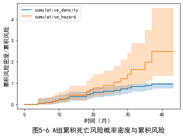

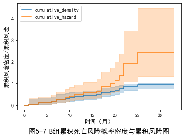

- **图5-6 和 图5-7**：分别展示了A组和B组的累积风险密度和累积风险曲线。这些图表显示了随时间变化的累积风险，可以帮助我们理解在不同时间点上死亡风险的累积情况。
- **图5-8**：比较了A组和B组的累积风险密度。如果某组的曲线始终高于另一组，这表明该组在相应时间点的累积死亡风险更高。
- **图5-9**：比较了A组和B组的累积风险。同样，如果某组的曲线始终高于另一组，这表明该组的累积死亡风险更高。

### 结论

- **累积风险比较**：通过比较A组和B组的累积风险曲线，可以评估不同治疗或条件对累积死亡风险的影响。
- **统计显著性**：虽然这里没有直接提供统计检验的结果，但通过观察累积风险曲线的差异，可以初步判断两组之间的风险差异。
- **置信区间**：累积风险的置信区间提供了风险估计的不确定性范围，如果两组的置信区间在某些时间点上没有重叠，这可能表明两组在这些时间点上的风险差异具有统计学意义。

总的来说，这些结果提供了关于A组和B组累积死亡风险的比较，有助于研究人员或医生评估治疗效果和制定医疗决策。

### 图表内容

1. **累积风险密度（Cumulative Density）**：
   - 蓝色曲线表示使用Kaplan-Meier方法估计的累积风险密度。它显示了在不同时间点之前死亡的概率。
2. **累积风险（Cumulative Hazard）**：
   - 橙色曲线表示使用Nelson-Aalen方法估计的累积风险。它显示了在不同时间点之前死亡的总风险。
3. **置信区间（Confidence Interval）**：
   - 曲线周围的阴影区域表示95%置信区间，反映了估计的不确定性。置信区间越宽，表示估计的不确定性越大。

### 图表解读

- **时间（月）**：横轴表示时间，以月为单位，显示了从开始观察到某个时间点的累积风险。
- **累积风险密度/累积风险**：纵轴表示累积风险密度或累积风险，即在特定时间点之前死亡的概率或风险。
- **曲线解读**：
  - 曲线的上升表示随着时间的推移，死亡的个体数量在增加。
  - 曲线的陡峭程度反映了在特定时间段内死亡事件的集中程度。如果曲线在某段时间内变得陡峭，这表明在这段时间内死亡事件较为集中。

### 结论

- **累积风险比较**：通过比较累积风险密度和累积风险曲线，可以评估在不同时间点的死亡风险。
- **置信区间**：置信区间提供了风险估计的不确定性范围，如果置信区间在某些时间点上较宽，这可能表明在这些时间点上的风险估计不太稳定。

### 图5-7 B组累积死亡风险概率密度与累积风险图

- **图5-7**：这张图综合了累积风险密度和累积风险的估计，提供了B组在不同时间点的死亡风险的全面视图。
- **图例**：图例显示了曲线对应的估计方法，帮助区分Kaplan-Meier和Nelson-Aalen方法的结果。

总的来说，这些图表提供了关于B组死亡风险随时间变化的直观比较，有助于研究人员或医生评估治疗效果和制定医疗决策。通过观察累积风险曲线，可以了解在不同时间段内死亡风险的累积情况。

以下是对您提供的B组生存分析结果的详细解读：

### 4-21 B组event_table（KM）

- **event_table**：这是Kaplan-Meier生存分析中的风险事件表，显示了在每个时间点上的风险人数（at_risk）、观察到的事件数（observed）、删失数（censored）以及新进入风险集的人数（entrance）。
- **removed**：表示在特定时间点上被移除的个体数量，可能是因为数据整理或模型拟合的需要。
- **observed**：表示在特定时间点上观察到的事件（如死亡）数量。
- **censored**：表示在特定时间点上删失的个体数量，即在该时间点上个体的确切生存状态未知。

### 4-22 B组累积风险密度cumulative_density（KM）

- **cumulative_density**：这是Kaplan-Meier方法估计的累积风险密度，表示在特定时间点之前死亡的概率。例如，在1个月时，累积风险密度为0.045455，表示大约有4.55%的B组患者在1个月之前死亡。

### 4-24 B组累积风险cumulative_hazard（NA）

- **cumulative_hazard**：这是Nelson-Aalen方法估计的累积风险，表示在特定时间点之前发生事件的总风险。例如，在22个月时，累积风险为1.923414，表示在22个月之前，B组的累积风险非常高。

### 4-25 B组累积风险95%置信区间CI_cumulative_hazard（NA）

- **CI_cumulative_hazard**：这是累积风险的95%置信区间，提供了累积风险估计的不确定性范围。例如，在22个月时，累积风险的95%置信区间为[1.078913, 3.428933]。

### 结论

- **累积风险比较**：通过比较Kaplan-Meier和Nelson-Aalen方法的累积风险密度和累积风险，可以评估在不同时间点的死亡风险。
- **置信区间**：累积风险的置信区间提供了风险估计的不确定性范围，如果置信区间在某些时间点上较宽，这可能表明在这些时间点上的风险估计不太稳定。
- **风险事件表**：风险事件表提供了在每个时间点上的风险人数、观察到的事件数、删失数和新进入风险集的人数，这些信息对于理解数据的动态变化非常重要。

总的来说，这些结果提供了关于B组死亡风险随时间变化的直观比较，有助于研究人员或医生评估治疗效果和制定医疗决策。通过观察累积风险曲线，可以了解在不同时间段内死亡风险的累积情况。

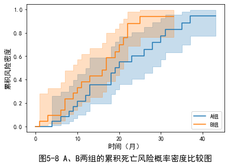

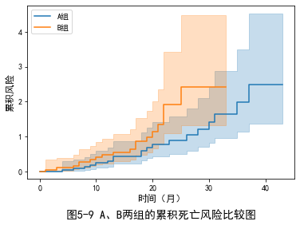

5-9AB累积死亡风险

这两张图分别展示了A组和B组的累积死亡风险概率密度和累积风险的比较。以下是对每个图的详细解读：

### 图5-8 A、B两组的累积死亡风险概率密度比较图

1. **累积风险概率密度**：这张图展示了A组和B组在不同时间点的累积死亡风险概率密度。累积风险概率密度是生存函数的补数，表示在特定时间点之前死亡的概率。
2. **时间（月）**：横轴表示时间，以月为单位。
3. **累积风险概率密度**：纵轴表示累积风险概率密度，即在特定时间点之前死亡的概率。
4. **曲线解读**：
   - 蓝色曲线代表A组，橙色曲线代表B组。
   - 曲线的上升表示随着时间的推移，死亡的个体数量在增加。
   - 如果A组的曲线始终低于B组，这表明在相同的时间点，A组的累积死亡概率较低，即A组的生存情况相对较好。
5. **置信区间**：曲线周围的阴影区域表示95%置信区间，反映了累积风险概率密度估计的不确定性。

### 图5-9 A、B两组的累积死亡风险比较图

1. **累积风险**：这张图展示了A组和B组在不同时间点的累积风险。累积风险表示在特定时间点之前发生事件的总风险。
2. **时间（月）**：横轴同样表示时间，以月为单位。
3. **累积风险**：纵轴表示累积风险，即在特定时间点之前死亡的总风险。
4. **曲线解读**：
   - 同样，蓝色曲线代表A组，橙色曲线代表B组。
   - 曲线的上升表示死亡风险的累积。
   - 如果B组的曲线上升更快，这可能表明B组的死亡风险更高。
5. **置信区间**：曲线周围的阴影区域表示95%置信区间，提供了累积风险估计的不确定性范围。

### 结论

- **风险比较**：通过比较A组和B组的累积风险概率密度和累积风险曲线，可以评估不同组别在不同时间点的死亡风险。
- **生存情况评估**：如果A组的曲线始终低于B组，这可能表明A组的治疗或条件更有利于降低死亡风险。
- **统计显著性**：虽然图中没有直接提供统计检验的结果，但通过观察累积风险曲线的差异，可以初步判断两组之间的风险差异。

总的来说，这些图表提供了关于A组和B组死亡风险随时间变化的直观比较，有助于研究人员或医生评估治疗效果和制定医疗决策。